## Big Ten East Football Recruiting: An Analysis, Spring 2020

By Andrew Datovech for CMSC320

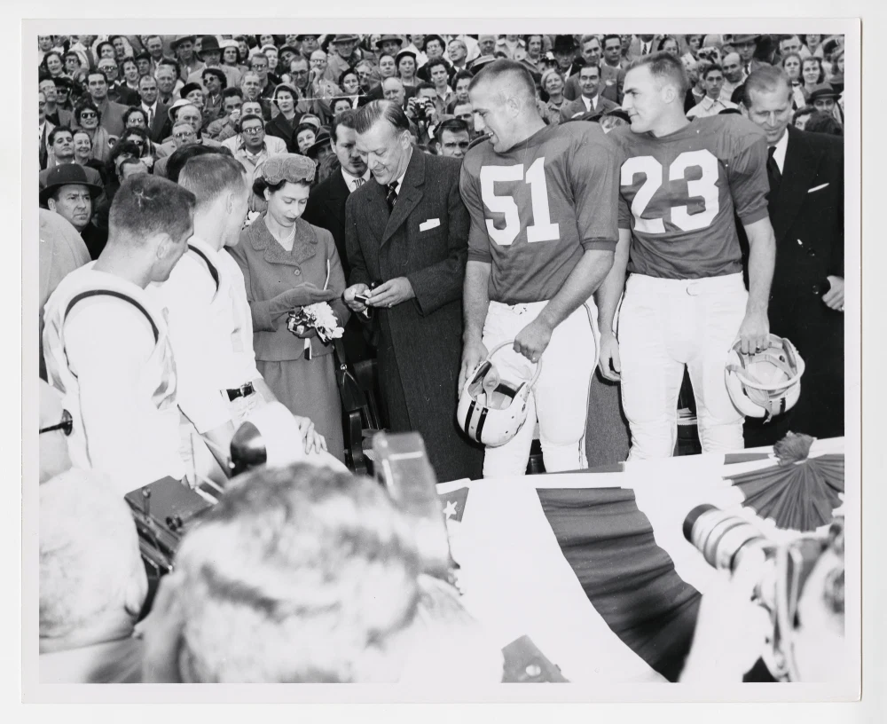

[Queen Elizabeth II attends a Maryland Terrapins football game at Maryland Stadium.](https://umdarchives.wordpress.com/tag/queens-game/#jp-carousel-11536)

## Introduction

To call me a die-hard Maryland Terrapins football fan would be an understatement. Despite the team’s abysmal record during my two years at the university, earning a combined win-loss record of [8-16](https://www.sports-reference.com/cfb/schools/maryland/index.html), I have attended each game (yes, even the Penn State game) in the desperate hopes of witnessing a bowl-game season. Perhaps I was conditioned improperly: my first game as a freshman was a [weather-delayed](https://www.espn.com/college-football/game?gameId=401012872) break from reality. Maryland beat ranked Texas for the second year in a row to sweep their series, in a game played halfway around the Beltway from campus. I am not kidding when I mention the “die-hard” aspect of my fandom, either, as my 2019 season began with a trip to the emergency room, after watching the Terrapins’ 79-0 dismantling of Howard University resulted in severe heat illness. (You can see me, doomed to puke my guts out, right behind Coach Locksley at the 49:00 mark of [this video.](https://www.youtube.com/watch?v=Lssz5hxXRGk))

For those of you that care little for college football, and even less for Maryland football, I am sure that this project seems to provide little value at first glance. However, I want to provide an accessible view into the data science pipeline for fans of college athletics, as the marriage of sports and data science has yielded some [awesome results](https://fivethirtyeight.com/sports/).

## Necessary Information

This analysis was performed in the [R programming language](https://en.wikipedia.org/wiki/R_language), which is a programming language for statistics and data analysis. Specifically, RStudio was used to “knit”, or run and output the results of, my RMarkdown document that contains code and text to HTML. HTML is the webpage format that your browser most commonly uses.

The University of Maryland plays football in the [Big Ten](https://www.sports-reference.com/cfb/conferences/big-ten/2019.html) athletic conference. Despite its confusing name, the “Big Ten” has 14 universities that compete in football. Since the regular season in college football lasts for only 12 games, each school can not play all of the other members each year. Thus, the conference splits into two “divisions” of seven schools by geography, [East and West](https://www.sports-reference.com/cfb/conferences/big-ten/2019.html). This groups Maryland in the East division with Ohio State, Penn State, Michigan, Indiana, Michigan State, and Rutgers, against whom Maryland must play each season. Since this is the only constant between all of these teams’ schedules, the number of division wins in a given year (0-6) can be defined as the metric of success.

## The Problem

As mentioned, Maryland has only won one-third of their football games played during my time as a student, and I want to help explain this relative lack of performance. In CMSC320, we explored how in-game performance in the sport of baseball can be used to demonstrate a player’s [future value](https://www.hcbravo.org/IntroDataSci/projects/project2/). Instead of focusing on retrospective indicators (touchdowns scored, quarterback rating, turnover ratio, etc.), I chose to investigate something else: indicators of recruiting success.

In college football, as in other sports, the business of assessing, attracting, and enrolling future star athletes is a [massive and often ethically questionable](https://www.bannersociety.com/2014/4/10/20703758/bag-man-paying-college-football-players) program function. In fact, large sports journalism sources like ESPN [charge fans](http://insider.espn.com/college-sports/football/recruiting/classrankings/rank/_/rank/5/class/2021/date/20200512) to access “insider” data on teams’ win prospects. A star system of ranking recruits has arisen to “solve” this problem, in which sports journalists and scouts rank incoming college players according to the following rating system (with examples provided):

[5 stars](https://247sports.com/Player/Caleb-Williams-46040610/): A rising star at the college level. Likely to play professional football.

[4 stars](https://247sports.com/player/demeioun-robinson-46082055/): A starting roster-quality player at the college level. A good chance to play professional football.

[3/2 stars](https://247sports.com/player/weston-wolff-46058901/): A scholarship-quality player at the college level. Unlikely to play professional football.

The key question, then, is this: What indicators, if any, in a Big Ten East team’s recruiting ratings influence its ability to win games?

## Part 1: Data Scraping and Cleaning

CBS Sports’ aptly named “247Sports” consolidates college recruits’ star ratings into a single, [composite](https://247sports.com/Season/2015-Football/CompositeTeamRankings/?Conference=Big-Ten) star rating, and combines these scores across teams to calculate teams’ recruiting class ranking, as well as an overall roster talent ranking. Let’s scrape this data for the past five seasons (2015-2019), and learn some more about data science in the process. I added prose comments in each chunk to help you follow along.

```r
library(stringr)
library(tidyverse)
# A data processing library
library(rvest)
# A Web scraping library
library(dplyr)
# A data "pipeline" library that helps us modify and transform data structures
url <- "https://247sports.com/Season/2015-Football/CollegeTeamTalentComposite/?Conference=Big-Ten"
team_names2015 <- url %>%
  read_html() %>%
  html_nodes(xpath='//*[@class="team"]') %>%
  html_text()
team_names2015 <- c(team_names2015)
team_names2015 <- team_names2015[-1]
# The scraped team names:
team_names2015
```

```
##  [1] "   Ohio State   "     "   Michigan   "       "   Penn State   "
##  [4] "   Michigan State   " "   Nebraska   "       "   Wisconsin   "
##  [7] "   Maryland   "       "   Rutgers   "        "   Northwestern   "
## [10] "   Iowa   "           "   Indiana   "        "   Purdue   "
## [13] "   Illinois   "       "   Minnesota   "
```

```r
commit_count2015 <- url %>%
  read_html() %>%
  html_nodes(xpath='//*[@class="total"]') %>%
  html_text()
commit_count2015 <- c(commit_count2015)
commit_count2015 <- commit_count2015[-1]
# The total number of scholarship players. Oh no! This formatted as a string? We'll deal with this later.
commit_count2015
```

```
##  [1] "   80 Commits   " "   84 Commits   " "   85 Commits   " "   85 Commits   "
##  [5] "   85 Commits   " "   83 Commits   " "   79 Commits   " "   80 Commits   "
##  [9] "   75 Commits   " "   81 Commits   " "   79 Commits   " "   84 Commits   "
## [13] "   77 Commits   " "   85 Commits   "
```

```r
star_count2015 <- url %>%
  read_html() %>%
  html_nodes(xpath='//*[@class="star-commits-list"]') %>%
  html_text()
star_count2015 <- c(star_count2015)
# This data set is not very "tidy" - one string, with inconsistent spacing, for three attributes? We will need to clean this attribute as well.
star_count2015
```

```
##  [1] " 5-Star   4    4-Star   49    3-Star  23   "
##  [2] " 5-Star   2    4-Star   42    3-Star  33   "
##  [3] " 5-Star   0    4-Star   22    3-Star  55   "
##  [4] " 5-Star   1    4-Star   17    3-Star  60   "
##  [5] " 5-Star   0    4-Star   21    3-Star  49   "
##  [6] " 5-Star   0    4-Star   8    3-Star  59   "
##  [7] " 5-Star   1    4-Star   6    3-Star  61   "
##  [8] " 5-Star   1    4-Star   8    3-Star  55   "
##  [9] " 5-Star   0    4-Star   6    3-Star  58   "
## [10] " 5-Star   0    4-Star   6    3-Star  58   "
## [11] " 5-Star   0    4-Star   2    3-Star  61   "
## [12] " 5-Star   0    4-Star   1    3-Star  64   "
## [13] " 5-Star   0    4-Star   2    3-Star  54   "
## [14] " 5-Star   0    4-Star   1    3-Star  65   "
```

```r
avg2015 <- url %>%
  read_html() %>%
  html_nodes(xpath='//*[@class="avg"]') %>%
  html_text()
avg2015 <- c(avg2015)
avg2015 <- avg2015[-1]
avg2015 <- as.numeric(avg2015)
# The average player rating on the roster, out of 100:
avg2015
```

```
##  [1] 90.86 88.60 85.40 86.09 83.67 83.80 83.30 82.59 83.69 81.67 82.51 81.60
## [13] 81.92 81.64
```

```r
number2015 <- url %>%
  read_html() %>%
  html_nodes(xpath='//*[@class="number"]') %>%
  html_text() %>%
  as.numeric()
number2015 <- c(number2015)
# A "cumulative talent" rating - a weighted product of a team's roster size and the previously mentioned talent metrics:
number2015
```

```
##  [1] 907.32 851.12 732.36 715.30 699.89 635.77 603.76 602.35 595.75 573.06
## [11] 559.08 534.26 530.96 516.10
```

```r
teamtalent2015 <- data.frame(Year=2015,Name=team_names2015,Total=commit_count2015,StarPlayers=star_count2015,Avg=avg2015,Points=number2015)
# Let's combine these columns scraped into a data frame!
teamtalent2015
```

```
##    Year                 Name            Total
## 1  2015        Ohio State       80 Commits
## 2  2015          Michigan       84 Commits
## 3  2015        Penn State       85 Commits
## 4  2015    Michigan State       85 Commits
## 5  2015          Nebraska       85 Commits
## 6  2015         Wisconsin       83 Commits
## 7  2015          Maryland       79 Commits
## 8  2015           Rutgers       80 Commits
## 9  2015      Northwestern       75 Commits
## 10 2015              Iowa       81 Commits
## 11 2015           Indiana       79 Commits
## 12 2015            Purdue       84 Commits
## 13 2015          Illinois       77 Commits
## 14 2015         Minnesota       85 Commits
##                                    StarPlayers   Avg Points
## 1   5-Star   4    4-Star   49    3-Star  23    90.86 907.32
## 2   5-Star   2    4-Star   42    3-Star  33    88.60 851.12
## 3   5-Star   0    4-Star   22    3-Star  55    85.40 732.36
## 4   5-Star   1    4-Star   17    3-Star  60    86.09 715.30
## 5   5-Star   0    4-Star   21    3-Star  49    83.67 699.89
## 6    5-Star   0    4-Star   8    3-Star  59    83.80 635.77
## 7    5-Star   1    4-Star   6    3-Star  61    83.30 603.76
## 8    5-Star   1    4-Star   8    3-Star  55    82.59 602.35
## 9    5-Star   0    4-Star   6    3-Star  58    83.69 595.75
## 10   5-Star   0    4-Star   6    3-Star  58    81.67 573.06
## 11   5-Star   0    4-Star   2    3-Star  61    82.51 559.08
## 12   5-Star   0    4-Star   1    3-Star  64    81.60 534.26
## 13   5-Star   0    4-Star   2    3-Star  54    81.92 530.96
## 14   5-Star   0    4-Star   1    3-Star  65    81.64 516.10
```

```r
new_cols <- str_split_fixed(teamtalent2015$StarPlayers,"[[:space:]]+",8)
new_cols <- data.frame(new_cols)
new_cols <- select(new_cols,c("X3","X5","X7"))
colnames(new_cols) <- c("Five","Four","Three")
# Time to clean up the first string and split it into 5 star, 4 star, and 3 star players:
new_cols
```

```
##    Five Four Three
## 1     4   49    23
## 2     2   42    33
## 3     0   22    55
## 4     1   17    60
## 5     0   21    49
## 6     0    8    59
## 7     1    6    61
## 8     1    8    55
## 9     0    6    58
## 10    0    6    58
## 11    0    2    61
## 12    0    1    64
## 13    0    2    54
## 14    0    1    65
```

```r
teamtalent2015 <- merge(teamtalent2015,new_cols,by.x=0,by.y=0)
teamtalent2015$Total <- as.character(teamtalent2015$Total)
teamtalent2015 <- mutate(teamtalent2015,Roster=parse_number(Total))
teamtalent2015$Five <- parse_number(as.character(teamtalent2015$Five))
teamtalent2015$Four <- parse_number(as.character(teamtalent2015$Four))
teamtalent2015$Three <- parse_number(as.character(teamtalent2015$Three))
teamtalent2015$Name <- parse_character(as.character(teamtalent2015$Name))
# Now we can remove the extraneous or non-tidy attributes, and convert "Roster" into an attribute representing zero-star players by substracting five, four, and three-star players.
teamtalent2015 <- teamtalent2015 %>%
  select(-"Row.names") %>%
  select(-Total) %>%
  select(-StarPlayers) %>%
  mutate(Zero=(Roster-Five-Four-Three)) %>%
  select(-Roster)
# Now this dataset is looking good!
teamtalent2015
```

```
##    Year           Name   Avg Points Five Four Three Zero
## 1  2015     Ohio State 90.86 907.32    4   49    23    4
## 2  2015           Iowa 81.67 573.06    0    6    58   17
## 3  2015        Indiana 82.51 559.08    0    2    61   16
## 4  2015         Purdue 81.60 534.26    0    1    64   19
## 5  2015       Illinois 81.92 530.96    0    2    54   21
## 6  2015      Minnesota 81.64 516.10    0    1    65   19
## 7  2015       Michigan 88.60 851.12    2   42    33    7
## 8  2015     Penn State 85.40 732.36    0   22    55    8
## 9  2015 Michigan State 86.09 715.30    1   17    60    7
## 10 2015       Nebraska 83.67 699.89    0   21    49   15
## 11 2015      Wisconsin 83.80 635.77    0    8    59   16
## 12 2015       Maryland 83.30 603.76    1    6    61   11
## 13 2015        Rutgers 82.59 602.35    1    8    55   16
## 14 2015   Northwestern 83.69 595.75    0    6    58   11
```

```r
# Let's get rid of those annoying Big Ten West teams by only allowing entities with the proper seven team names:
teamtalent2015 <- teamtalent2015[ (teamtalent2015$Name %in% c("Maryland","Penn State","Ohio State","Michigan","Michigan State","Indiana","Rutgers")), ]
teamtalent2015
```

```
##    Year           Name   Avg Points Five Four Three Zero
## 1  2015     Ohio State 90.86 907.32    4   49    23    4
## 3  2015        Indiana 82.51 559.08    0    2    61   16
## 7  2015       Michigan 88.60 851.12    2   42    33    7
## 8  2015     Penn State 85.40 732.36    0   22    55    8
## 9  2015 Michigan State 86.09 715.30    1   17    60    7
## 12 2015       Maryland 83.30 603.76    1    6    61   11
## 13 2015        Rutgers 82.59 602.35    1    8    55   16
```

```r
# Finally, we add the number of division wins in the year - there are no datasets to scrape for this, as only conference wins are tracked, which includes division and cross-divsion wins. For this, we'll use the following source to manually "scrape" the missing data: https://www.sports-reference.com/cfb/conferences/big-ten/2015-schedule.html
div_wins <- c(3,1,4,1,5,1,6)
div_winners <- c("Penn State","Rutgers","Michigan","Maryland","Ohio State","Indiana","Michigan State")
dw2015 <- data.frame(div_winners,div_wins)
dw2015$div_winners <- as.character(dw2015$div_winners)
dw2015
```

```
##      div_winners div_wins
## 1     Penn State        3
## 2        Rutgers        1
## 3       Michigan        4
## 4       Maryland        1
## 5     Ohio State        5
## 6        Indiana        1
## 7 Michigan State        6
```

```r
# Now let's put these frames together using data pipelines and a 'left join'!
teamtalent2015 <- teamtalent2015 %>%
  left_join(dw2015,by=c("Name" = "div_winners"))
teamtalent2015
```

```
##   Year           Name   Avg Points Five Four Three Zero div_wins
## 1 2015     Ohio State 90.86 907.32    4   49    23    4        5
## 2 2015        Indiana 82.51 559.08    0    2    61   16        1
## 3 2015       Michigan 88.60 851.12    2   42    33    7        4
## 4 2015     Penn State 85.40 732.36    0   22    55    8        3
## 5 2015 Michigan State 86.09 715.30    1   17    60    7        6
## 6 2015       Maryland 83.30 603.76    1    6    61   11        1
## 7 2015        Rutgers 82.59 602.35    1    8    55   16        1
```

Fantastic! Now we have a ‘tidy’ dataset for the year 2015! (each row represents a single team, each column represents a single attribute for that team).

This process then gets repeated for the seasons of 2016, 2017, 2018, and 2019, like so:

```r
url <- "https://247sports.com/Season/2016-Football/CollegeTeamTalentComposite/?Conference=Big-Ten"
team_names2016 <- url %>%
  read_html() %>%
  html_nodes(xpath='//*[@class="team"]') %>%
  html_text()
team_names2016 <- c(team_names2016)
team_names2016 <- team_names2016[-1]
commit_count2016 <- url %>%
  read_html() %>%
  html_nodes(xpath='//*[@class="total"]') %>%
  html_text()
commit_count2016 <- c(commit_count2016)
commit_count2016 <- commit_count2016[-1]
star_count2016 <- url %>%
  read_html() %>%
  html_nodes(xpath='//*[@class="star-commits-list"]') %>%
  html_text()
star_count2016 <- c(star_count2016)
avg2016 <- url %>%
  read_html() %>%
  html_nodes(xpath='//*[@class="avg"]') %>%
  html_text()
avg2016 <- c(avg2016)
avg2016 <- avg2016[-1]
avg2016 <- as.numeric(avg2016)
number2016 <- url %>%
  read_html() %>%
  html_nodes(xpath='//*[@class="number"]') %>%
  html_text() %>%
  as.numeric()
number2016 <- c(number2016)
teamtalent2016 <- data.frame(Year=2016,Name=team_names2016,Total=commit_count2016,StarPlayers=star_count2016,Avg=avg2016,Points=number2016)
new_cols <- str_split_fixed(teamtalent2016$StarPlayers,"[[:space:]]+",8)
new_cols <- data.frame(new_cols)
new_cols <- select(new_cols,c("X3","X5","X7"))
colnames(new_cols) <- c("Five","Four","Three")
teamtalent2016 <- merge(teamtalent2016,new_cols,by.x=0,by.y=0)
teamtalent2016$Total <- as.character(teamtalent2016$Total)
teamtalent2016 <- mutate(teamtalent2016,Roster=parse_number(Total))
teamtalent2016$Five <- parse_number(as.character(teamtalent2016$Five))
teamtalent2016$Four <- parse_number(as.character(teamtalent2016$Four))
teamtalent2016$Three <- parse_number(as.character(teamtalent2016$Three))
teamtalent2016$Name <- parse_character(as.character(teamtalent2016$Name))
teamtalent2016 <- teamtalent2016 %>%
  select(-"Row.names") %>%
  select(-Total) %>%
  select(-StarPlayers) %>%
  mutate(Zero=(Roster-Five-Four-Three)) %>%
  select(-Roster)
teamtalent2016 <- teamtalent2016[ (teamtalent2016$Name %in% c("Maryland","Penn State","Ohio State","Michigan","Michigan State","Indiana","Rutgers")), ]
# See the original version comment: https://www.sports-reference.com/cfb/conferences/big-ten/2016-schedule.html
div_wins <- c(5,0,5,2,5,3,1)
div_winners <- c("Penn State","Rutgers","Michigan","Maryland","Ohio State","Indiana","Michigan State")
dw2016 <- data.frame(div_winners,div_wins)
dw2016$div_winners <- as.character(dw2016$div_winners)
teamtalent2016 <- teamtalent2016 %>%
  left_join(dw2016,by=c("Name" = "div_winners"))
teamtalent2016
```

```
##   Year           Name   Avg Points Five Four Three Zero div_wins
## 1 2016     Ohio State 90.87 902.46    3   50    24    3        5
## 2 2016        Indiana 82.98 565.47    0    2    68   12        3
## 3 2016       Michigan 88.37 852.78    1   42    32   10        5
## 4 2016     Penn State 85.39 742.52    1   25    49   10        5
## 5 2016 Michigan State 86.38 719.70    0   21    57    7        1
## 6 2016       Maryland 83.92 651.99    1   10    56   14        2
## 7 2016        Rutgers 82.39 585.47    1    7    52   19        0
```

```r
url <- "https://247sports.com/Season/2017-Football/CollegeTeamTalentComposite/?Conference=Big-Ten"
team_names2017 <- url %>%
  read_html() %>%
  html_nodes(xpath='//*[@class="team"]') %>%
  html_text()
team_names2017 <- c(team_names2017)
team_names2017 <- team_names2017[-1]
commit_count2017 <- url %>%
  read_html() %>%
  html_nodes(xpath='//*[@class="total"]') %>%
  html_text()
commit_count2017 <- c(commit_count2017)
commit_count2017 <- commit_count2017[-1]
star_count2017 <- url %>%
  read_html() %>%
  html_nodes(xpath='//*[@class="star-commits-list"]') %>%
  html_text()
star_count2017 <- c(star_count2017)
avg2017 <- url %>%
  read_html() %>%
  html_nodes(xpath='//*[@class="avg"]') %>%
  html_text()
avg2017 <- c(avg2017)
avg2017 <- avg2017[-1]
avg2017 <- as.numeric(avg2017)
number2017 <- url %>%
  read_html() %>%
  html_nodes(xpath='//*[@class="number"]') %>%
  html_text() %>%
  as.numeric()
number2017 <- c(number2017)
teamtalent2017 <- data.frame(Year=2017,Name=team_names2017,Total=commit_count2017,StarPlayers=star_count2017,Avg=avg2017,Points=number2017)
new_cols <- str_split_fixed(teamtalent2017$StarPlayers,"[[:space:]]+",8)
new_cols <- data.frame(new_cols)
new_cols <- select(new_cols,c("X3","X5","X7"))
colnames(new_cols) <- c("Five","Four","Three")
teamtalent2017 <- merge(teamtalent2017,new_cols,by.x=0,by.y=0)
teamtalent2017$Total <- as.character(teamtalent2017$Total)
teamtalent2017 <- mutate(teamtalent2017,Roster=parse_number(Total))
teamtalent2017$Five <- parse_number(as.character(teamtalent2017$Five))
teamtalent2017$Four <- parse_number(as.character(teamtalent2017$Four))
teamtalent2017$Three <- parse_number(as.character(teamtalent2017$Three))
teamtalent2017$Name <- parse_character(as.character(teamtalent2017$Name))
teamtalent2017 <- teamtalent2017 %>%
  select(-"Row.names") %>%
  select(-Total) %>%
  select(-StarPlayers) %>%
  mutate(Zero=(Roster-Five-Four-Three)) %>%
  select(-Roster)
teamtalent2017 <- teamtalent2017[ (teamtalent2017$Name %in% c("Maryland","Penn State","Ohio State","Michigan","Michigan State","Indiana","Rutgers")), ]
# See the original version comment: https://www.sports-reference.com/cfb/conferences/big-ten/2017-schedule.html
div_wins <- c(4,1,3,1,6,1,5)
div_winners <- c("Penn State","Rutgers","Michigan","Maryland","Ohio State","Indiana","Michigan State")
dw2017 <- data.frame(div_winners,div_wins)
dw2017$div_winners <- as.character(dw2017$div_winners)
teamtalent2017 <- teamtalent2017 %>%
  left_join(dw2017,by=c("Name" = "div_winners"))
teamtalent2017
```

```
##   Year           Name   Avg Points Five Four Three Zero div_wins
## 1 2017     Ohio State 92.13 955.51    7   56    20    2        6
## 2 2017        Rutgers 83.15 574.81    0    7    59   13        1
## 3 2017        Indiana 82.84 547.92    0    0    72    9        1
## 4 2017       Michigan 89.94 874.89    3   46    33    3        3
## 5 2017     Penn State 87.89 779.49    1   33    48    3        4
## 6 2017       Maryland 85.17 696.31    1   17    57   10        1
## 7 2017 Michigan State 85.58 680.94    0   17    59    7        5
```

```r
url <- "https://247sports.com/Season/2018-Football/CollegeTeamTalentComposite/?Conference=Big-Ten"
team_names2018 <- url %>%
  read_html() %>%
  html_nodes(xpath='//*[@class="team"]') %>%
  html_text()
team_names2018 <- c(team_names2018)
team_names2018 <- team_names2018[-1]
commit_count2018 <- url %>%
  read_html() %>%
  html_nodes(xpath='//*[@class="total"]') %>%
  html_text()
commit_count2018 <- c(commit_count2018)
commit_count2018 <- commit_count2018[-1]
star_count2018 <- url %>%
  read_html() %>%
  html_nodes(xpath='//*[@class="star-commits-list"]') %>%
  html_text()
star_count2018 <- c(star_count2018)
avg2018 <- url %>%
  read_html() %>%
  html_nodes(xpath='//*[@class="avg"]') %>%
  html_text()
avg2018 <- c(avg2018)
avg2018 <- avg2018[-1]
avg2018 <- as.numeric(avg2018)
number2018 <- url %>%
  read_html() %>%
  html_nodes(xpath='//*[@class="number"]') %>%
  html_text() %>%
  as.numeric()
number2018 <- c(number2018)
teamtalent2018 <- data.frame(Year=2018,Name=team_names2018,Total=commit_count2018,StarPlayers=star_count2018,Avg=avg2018,Points=number2018)
new_cols <- str_split_fixed(teamtalent2018$StarPlayers,"[[:space:]]+",8)
new_cols <- data.frame(new_cols)
new_cols <- select(new_cols,c("X3","X5","X7"))
colnames(new_cols) <- c("Five","Four","Three")
teamtalent2018 <- merge(teamtalent2018,new_cols,by.x=0,by.y=0)
teamtalent2018$Total <- as.character(teamtalent2018$Total)
teamtalent2018 <- mutate(teamtalent2018,Roster=parse_number(Total))
teamtalent2018$Five <- parse_number(as.character(teamtalent2018$Five))
teamtalent2018$Four <- parse_number(as.character(teamtalent2018$Four))
teamtalent2018$Three <- parse_number(as.character(teamtalent2018$Three))
teamtalent2018$Name <- parse_character(as.character(teamtalent2018$Name))
teamtalent2018 <- teamtalent2018 %>%
  select(-"Row.names") %>%
  select(-Total) %>%
  select(-StarPlayers) %>%
  mutate(Zero=(Roster-Five-Four-Three)) %>%
  select(-Roster)
teamtalent2018 <- teamtalent2018[ (teamtalent2018$Name %in% c("Maryland","Penn State","Ohio State","Michigan","Michigan State","Indiana","Rutgers")), ]
# See the original version comment: https://www.sports-reference.com/cfb/conferences/big-ten/2018-schedule.html
div_wins <- c(3,0,5,1,6,2,4)
div_winners <- c("Penn State","Rutgers","Michigan","Maryland","Ohio State","Indiana","Michigan State")
dw2018 <- data.frame(div_winners,div_wins)
dw2018$div_winners <- as.character(dw2018$div_winners)
teamtalent2018 <- teamtalent2018 %>%
  left_join(dw2018,by=c("Name" = "div_winners"))
teamtalent2018
```

```
##   Year           Name   Avg Points Five Four Three Zero div_wins
## 1 2018     Ohio State 92.89 984.30   11   55    17    2        6
## 2 2018        Indiana 83.47 564.40    0    0    77    6        2
## 3 2018        Rutgers 83.33 561.12    0    5    59   10        0
## 4 2018       Michigan 89.64 863.26    4   40    39    2        5
## 5 2018     Penn State 88.64 834.38    4   37    39    5        3
## 6 2018       Maryland 85.92 725.52    2   17    58    8        1
## 7 2018 Michigan State 86.09 687.18    0   14    67    4        4
```

```r
url <- "https://247sports.com/Season/2019-Football/CollegeTeamTalentComposite/?Conference=Big-Ten"
team_names2019 <- url %>%
  read_html() %>%
  html_nodes(xpath='//*[@class="team"]') %>%
  html_text()
team_names2019 <- c(team_names2019)
team_names2019 <- team_names2019[-1]
commit_count2019 <- url %>%
  read_html() %>%
  html_nodes(xpath='//*[@class="total"]') %>%
  html_text()
commit_count2019 <- c(commit_count2019)
commit_count2019 <- commit_count2019[-1]
star_count2019 <- url %>%
  read_html() %>%
  html_nodes(xpath='//*[@class="star-commits-list"]') %>%
  html_text()
star_count2019 <- c(star_count2019)
avg2019 <- url %>%
  read_html() %>%
  html_nodes(xpath='//*[@class="avg"]') %>%
  html_text()
avg2019 <- c(avg2019)
avg2019 <- avg2019[-1]
avg2019 <- as.numeric(avg2019)
number2019 <- url %>%
  read_html() %>%
  html_nodes(xpath='//*[@class="number"]') %>%
  html_text() %>%
  as.numeric()
number2019 <- c(number2019)
teamtalent2019 <- data.frame(Year=2019,Name=team_names2019,Total=commit_count2019,StarPlayers=star_count2019,Avg=avg2019,Points=number2019)
new_cols <- str_split_fixed(teamtalent2019$StarPlayers,"[[:space:]]+",8)
new_cols <- data.frame(new_cols)
new_cols <- select(new_cols,c("X3","X5","X7"))
colnames(new_cols) <- c("Five","Four","Three")
teamtalent2019 <- merge(teamtalent2019,new_cols,by.x=0,by.y=0)
teamtalent2019$Total <- as.character(teamtalent2019$Total)
teamtalent2019 <- mutate(teamtalent2019,Roster=parse_number(Total))
teamtalent2019$Five <- parse_number(as.character(teamtalent2019$Five))
teamtalent2019$Four <- parse_number(as.character(teamtalent2019$Four))
teamtalent2019$Three <- parse_number(as.character(teamtalent2019$Three))
teamtalent2019$Name <- parse_character(as.character(teamtalent2019$Name))
teamtalent2019 <- teamtalent2019 %>%
  select(-"Row.names") %>%
  select(-Total) %>%
  select(-StarPlayers) %>%
  mutate(Zero=(Roster-Five-Four-Three)) %>%
  select(-Roster)
teamtalent2019 <- teamtalent2019[ (teamtalent2019$Name %in% c("Maryland","Penn State","Ohio State","Michigan","Michigan State","Indiana","Rutgers")), ]
# See the original version comment: https://www.sports-reference.com/cfb/conferences/big-ten/2019-schedule.html
div_wins <- c(5,0,4,1,6,2,3)
div_winners <- c("Penn State","Rutgers","Michigan","Maryland","Ohio State","Indiana","Michigan State")
dw2019 <- data.frame(div_winners,div_wins)
dw2019$div_winners <- as.character(dw2019$div_winners)
teamtalent2019 <- teamtalent2019 %>%
  left_join(dw2019,by=c("Name" = "div_winners"))
teamtalent2019
```

```
##   Year           Name   Avg Points Five Four Three Zero div_wins
## 1 2019     Ohio State 92.37 973.56   13   47    25    0        6
## 2 2019        Indiana 84.11 603.81    0    4    71    8        2
## 3 2019        Rutgers 83.65 587.28    0    4    68   10        0
## 4 2019     Penn State 89.80 857.34    4   46    25    4        5
## 5 2019       Michigan 88.98 853.40    4   36    38    7        4
## 6 2019       Maryland 85.94 703.94    0   15    63    6        1
## 7 2019 Michigan State 85.96 688.74    0   13    66    6        3
```

Now, let’s combine these five year data frames into a single, cleaned data frame, ready for exploration and analysis.

```r
master <- rbind(teamtalent2015,teamtalent2016,teamtalent2017,teamtalent2018,teamtalent2019)
master
```

```
##    Year           Name   Avg Points Five Four Three Zero div_wins
## 1  2015     Ohio State 90.86 907.32    4   49    23    4        5
## 2  2015        Indiana 82.51 559.08    0    2    61   16        1
## 3  2015       Michigan 88.60 851.12    2   42    33    7        4
## 4  2015     Penn State 85.40 732.36    0   22    55    8        3
## 5  2015 Michigan State 86.09 715.30    1   17    60    7        6
## 6  2015       Maryland 83.30 603.76    1    6    61   11        1
## 7  2015        Rutgers 82.59 602.35    1    8    55   16        1
## 8  2016     Ohio State 90.87 902.46    3   50    24    3        5
## 9  2016        Indiana 82.98 565.47    0    2    68   12        3
## 10 2016       Michigan 88.37 852.78    1   42    32   10        5
## 11 2016     Penn State 85.39 742.52    1   25    49   10        5
## 12 2016 Michigan State 86.38 719.70    0   21    57    7        1
## 13 2016       Maryland 83.92 651.99    1   10    56   14        2
## 14 2016        Rutgers 82.39 585.47    1    7    52   19        0
```

[output cut: 21 more lines]

## Part 2: Exploratory Data Analysis

Before we proceed with the fancy statistics and machine learning, a major part of the data science pipeline is exploratory data analysis. Simply put, this is visualizing the data in different ways to gain insights before we dive in. We begin with a simple scatterplot of the team’s total talent points rating against the number of wins:

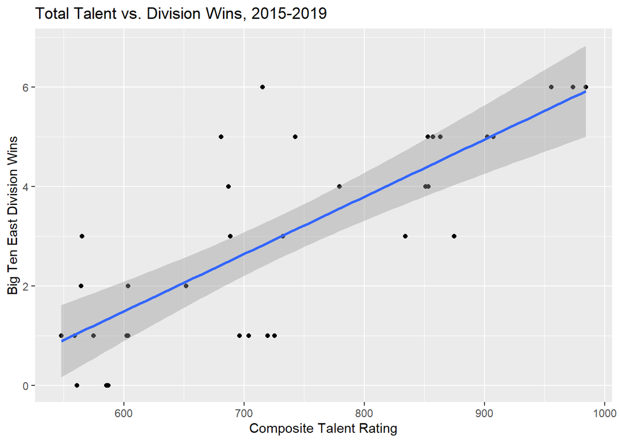

```r
ggplot(data=master,aes(x=Points,y=div_wins)) + geom_point() + labs(title="Total Talent vs. Division Wins, 2015-2019") + xlab("Composite Talent Rating") + ylab("Big Ten East Division Wins") + geom_smooth(method=lm)
```

Fascinating! We can see what appears to be a positive linear correlation between composite talent and division wins, although there appear to be some outliers in both the positive and negative direction.

Repeating with average player talent:

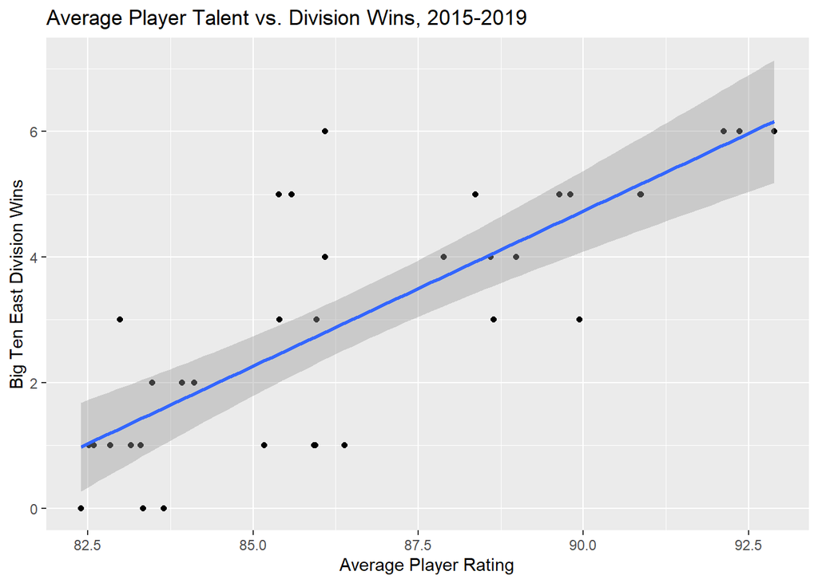

```r
ggplot(data=master,aes(x=Avg,y=div_wins)) + geom_point() + labs(title="Average Player Talent vs. Division Wins, 2015-2019") + xlab("Average Player Rating") + ylab("Big Ten East Division Wins") + geom_smooth(method=lm)
```

Here, we see a very similar trend, a strong positive correlation with some outliers. To look at an expected negative correlation, let’s try the number of zero-star (unranked) recruits against division wins:

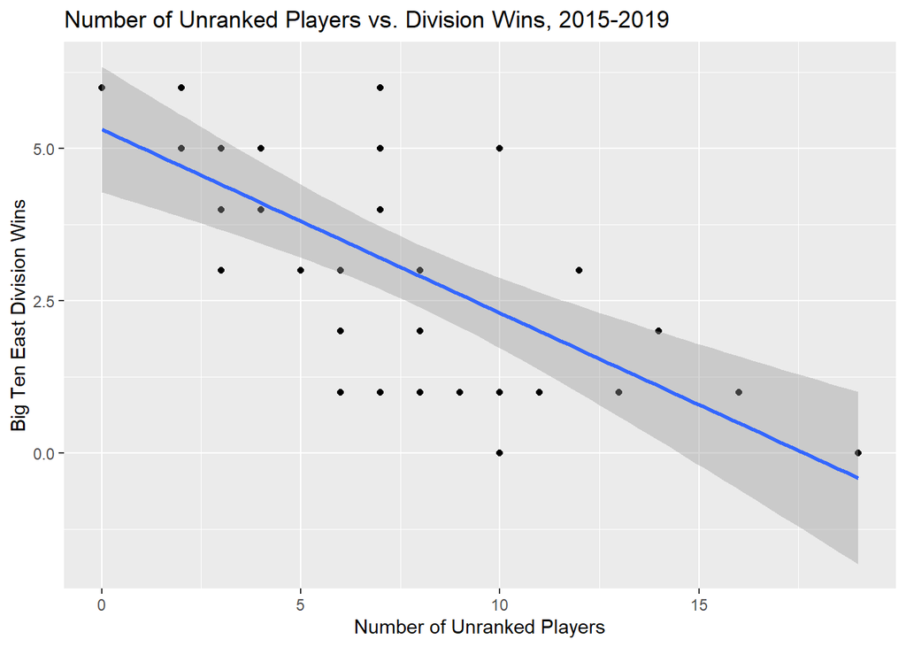

```r
ggplot(data=master,aes(x=Zero,y=div_wins)) + geom_point() + labs(title="Number of Unranked Players vs. Division Wins, 2015-2019") + xlab("Number of Unranked Players") + ylab("Big Ten East Division Wins") + geom_smooth(method=lm)
```

Here, we see a moderately negative correlation, with slightly lower variance than both of the first two predictors. For one last idea, let’s use the color feature in ggplot to help us visualize if particular teams are responsible for some of this variance.

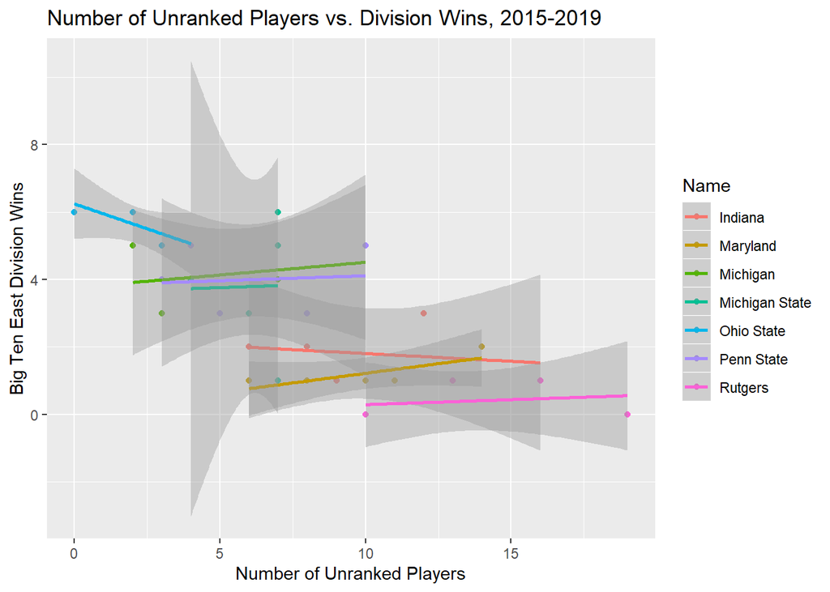

```r
ggplot(data=master,aes(x=Zero,y=div_wins,color=Name)) + geom_point() + labs(title="Number of Unranked Players vs. Division Wins, 2015-2019") + xlab("Number of Unranked Players") + ylab("Big Ten East Division Wins") + geom_smooth(method=lm)
```

Here, we see that Michigan and Penn State overperform the overall trendline on average, with higher numbers of unranked recruits than expected, while Maryland underperforms the trendline, with lower numbers of unranked recruits than expected. Also, Michigan State has massive variance compared to the other six teams.

## Part 3: Hypothesis Testing and Machine Learning

After viewing these plots, we can see what appears to be a linear trend involving all of the examined explanatory variables. This leads us to the third prong of the data science process, [hypothesis testing](https://www.britannica.com/science/statistics/Hypothesis-testing) and [machine learning](https://www.mathworks.com/discovery/machine-learning.html).

Here, we will use the lm() function in R, that provides a solution to the optimization problem of linear regression. In machine learning terms, this is an efficient algorithm that minimizes loss, or “least-squares” (squared variance, or difference between the model and the result). If you have a strong background in calculus, you can read more about how this problem is solved with “gradient descent” [here](https://www.hcbravo.org/IntroDataSci/bookdown-notes/solving-linear-ml-problems.html).

Let’s begin with a Big Ten East wins model that factors in all six available predictors - average player rating, 247’s “composite” team score, and the number of five-star, four-star, three-star, and unranked recruits on a roster. For this model, the null hypothesis will be that there is no correlation between any of these factors and success in the Big Ten East.

```r
model1 <- lm(div_wins~Avg+Points+Five+Four+Three+Zero,data=master)
summary(model1)
```

```
##
## Call:
## lm(formula = div_wins ~ Avg + Points + Five + Four + Three +
##     Zero, data = master)
##
## Residuals:
##     Min      1Q  Median      3Q     Max
## -2.0810 -0.4819  0.1363  0.3711  3.0661
##
## Coefficients:
##               Estimate Std. Error t value Pr(>|t|)
## (Intercept) -5.5375196 65.4027505  -0.085    0.933
## Avg         -0.0147984  0.7956891  -0.019    0.985
## Points       0.0035827  0.0194317   0.184    0.855
## Five         0.1020551  0.2430788   0.420    0.678
## Four         0.1219654  0.2162139   0.564    0.577
## Three        0.0833829  0.1402377   0.595    0.557
## Zero         0.0006091  0.2392439   0.003    0.998
##
## Residual standard error: 1.311 on 28 degrees of freedom
## Multiple R-squared:  0.6408, Adjusted R-squared:  0.5638
## F-statistic: 8.326 on 6 and 28 DF,  p-value: 3.159e-05
```

Let’s consider the null hypothesis - that there is no linear correlation between the factors and Big Ten East wins. An adjusted $R^2$ of $0.5638$ tells us that, accounting for sequential variables, about 56.38% of Big Ten East success can be explained by this model. The p-value of about $3.2e-05$, less than the level of significance of $0.05$, leads us to reject the null hypothesis. There is a linear correlation between at least one of these factors and Big Ten East wins.

However, one of the important assumptions in multiple linear regression is that each variable is related to the model. To be more precise, we are looking for a t-value for each explanatory variable (like five-star players) that leads to a p-value of less than $0.05$. High p-values like the ones in the model may be an indication of multicollinearity, or variables with overlap in predictive power. As we can see from the lm() output, there is no individual factor that comes close to that criteria. Let’s consider, then, a reduced model. We’ll remove the variable with the highest p-value or weakest individual correlation, zero-star recruits.

```r
model2 <- lm(div_wins~Avg+Points+Five+Four+Three,data=master)
summary(model2)
```

```
##
## Call:
## lm(formula = div_wins ~ Avg + Points + Five + Four + Three, data = master)
##
## Residuals:
##     Min      1Q  Median      3Q     Max
## -2.0804 -0.4821  0.1371  0.3713  3.0663
##
## Coefficients:
##              Estimate Std. Error t value Pr(>|t|)
## (Intercept) -5.406183  39.502048  -0.137    0.892
## Avg         -0.016290   0.529154  -0.031    0.976
## Points       0.003616   0.014191   0.255    0.801
## Five         0.101805   0.218388   0.466    0.645
## Four         0.121649   0.173776   0.700    0.489
## Three        0.083102   0.084900   0.979    0.336
##
## Residual standard error: 1.288 on 29 degrees of freedom
## Multiple R-squared:  0.6408, Adjusted R-squared:  0.5789
## F-statistic: 10.35 on 5 and 29 DF,  p-value: 9.073e-06
```

Again, we reject the null hypothesis ($p=9.073e-06 < 0.05$), and the reduced values in the Pr(>|t|) column indicate that we have reduced multicollinearity in the reduced model. However, these p-values are still too high to support the assumptions of this model. Let’s test a model with the 247 “average player rating” removed:

```r
model3 <- lm(div_wins~Points+Five+Four+Three,data=master)
summary(model3)
```

```
##
## Call:
## lm(formula = div_wins ~ Points + Five + Four + Three, data = master)
##
## Residuals:
##     Min      1Q  Median      3Q     Max
## -2.0833 -0.4786  0.1356  0.3691  3.0639
##
## Coefficients:
##              Estimate Std. Error t value Pr(>|t|)
## (Intercept) -6.608751   5.765792  -1.146    0.261
## Points       0.003569   0.013871   0.257    0.799
## Five         0.097418   0.162714   0.599    0.554
## Four         0.118273   0.132537   0.892    0.379
## Three        0.081400   0.063362   1.285    0.209
##
## Residual standard error: 1.267 on 30 degrees of freedom
## Multiple R-squared:  0.6408, Adjusted R-squared:  0.5929
## F-statistic: 13.38 on 4 and 30 DF,  p-value: 2.269e-06
```

Making progress, but still not there! ($p=2.269e-06$) Let’s remove the 247 “composite team talent” rating and try to resolve this multicollinearity:

```r
model4 <- lm(div_wins~Five+Four+Three,data=master)
summary(model4)
```

```
##
## Call:
## lm(formula = div_wins ~ Five + Four + Three, data = master)
##
## Residuals:
##     Min      1Q  Median      3Q     Max
## -2.0728 -0.4676  0.1063  0.3841  3.1248
##
## Coefficients:
##             Estimate Std. Error t value Pr(>|t|)
## (Intercept) -5.37685    3.16329  -1.700  0.09919 .
## Five         0.12744    0.11167   1.141  0.26253
## Four         0.15078    0.03940   3.827  0.00059 ***
## Three        0.09269    0.04502   2.059  0.04799 *
## ---
## Signif. codes:  0 '***' 0.001 '**' 0.01 '*' 0.05 '.' 0.1 ' ' 1
##
## Residual standard error: 1.247 on 31 degrees of freedom
## Multiple R-squared:   0.64,  Adjusted R-squared:  0.6052
## F-statistic: 18.37 on 3 and 31 DF,  p-value: 4.907e-07
```

Now, we can see that two explanatory variables (four and three-star recruits) appear to satisfy the assumptions of the linear model ($p<0.05$). Thus, we remove the remaining variable, five-star recruits:

```r
model5 <- lm(div_wins~Four+Three,data=master)
summary(model5)
```

```
##
## Call:
## lm(formula = div_wins ~ Four + Three, data = master)
##
## Residuals:
##     Min      1Q  Median      3Q     Max
## -2.2001 -0.6442 -0.0387  0.4866  3.1778
##
## Coefficients:
##             Estimate Std. Error t value Pr(>|t|)
## (Intercept) -4.21500    3.00909  -1.401  0.17091
## Four         0.15047    0.03958   3.801  0.00061 ***
## Three        0.07465    0.04235   1.763  0.08750 .
## ---
## Signif. codes:  0 '***' 0.001 '**' 0.01 '*' 0.05 '.' 0.1 ' ' 1
##
## Residual standard error: 1.253 on 32 degrees of freedom
## Multiple R-squared:  0.6249, Adjusted R-squared:  0.6014
## F-statistic: 26.65 on 2 and 32 DF,  p-value: 1.537e-07
```

At the 10% level of significance, we would retain three-star recruits in our model as an explanatory variable ($p~=0.09<0.1$), but since we are operating at the 5% level, we remove this variable from our model:

```r
model6 <- lm(div_wins~Four,data=master)
summary(model6)
```

```
##
## Call:
## lm(formula = div_wins ~ Four, data = master)
##
## Residuals:
##     Min      1Q  Median      3Q     Max
## -1.9126 -0.9413 -0.0538  0.6007  3.5201
##
## Coefficients:
##             Estimate Std. Error t value Pr(>|t|)
## (Intercept)  1.05383    0.35779   2.945  0.00587 **
## Four         0.08389    0.01221   6.869 7.66e-08 ***
## ---
## Signif. codes:  0 '***' 0.001 '**' 0.01 '*' 0.05 '.' 0.1 ' ' 1
##
## Residual standard error: 1.293 on 33 degrees of freedom
## Multiple R-squared:  0.5885, Adjusted R-squared:  0.576
## F-statistic: 47.19 on 1 and 33 DF,  p-value: 7.657e-08
```

We are now operating in single linear regression, modeling the number of four-star recruits as the best predictor of Big Ten East success. We can see this reflected in the adjusted $R^2$ of each model, which hardly varies from about $0.57<R^2<0.62$. This indicates a high degree of multicollinearity in the previous models, or the idea that the other variables we explored had predictive overlap with the number of four-star recruits. Since the p-value for the model is $7.657e-08<0.05$, we reject the null hypothesis.

## Part 4: Conclusion and Takeaways

At the 5% level of significance, we can say that the single best predictor of Big Ten East success, responsible for explaining about 58% of division wins, is the number of four-star recruits on a roster. On average, for each additional four-star recruit, a Big Ten East team wins $0.08389$ additional games, with an intercept (baseline) of $1.05383$ average division wins for a team with zero four-star recruits.

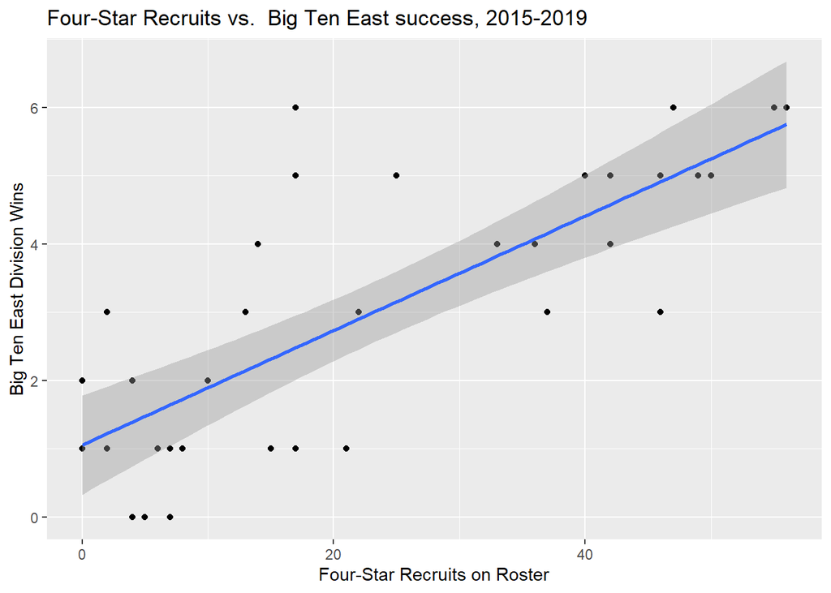

```r
ggplot(data=master,aes(x=Four,y=div_wins)) + geom_point() + labs(title="Four-Star Recruits vs.  Big Ten East success, 2015-2019") + xlab("Four-Star Recruits on Roster") + ylab("Big Ten East Division Wins") + geom_smooth(method=lm)
```

This has fascinating implications: in each of the examined linear models, four-star recruits had a larger per-recruit impact on a team’s average division wins than did five-star recruits. At a qualitative level, this may stem from expected behavior of higher-level recruits: five-star recruits, as shown above, are considered to be more likely to play professional football. Thus, four-star recruits might stay with their team longer, and be more likely to play as upperclassmen, that are more likely to be [program starters](https://umterps.com/sports/football/stats). All of these possibilities are due for further exploration, but the result remains the same: four-star players have a higher impact on wins in the Big Ten East than do their five-star counterparts.

As of the time of this article’s writing (May 18, 2020), the current four-star recruiting race in the [Big Ten East](https://247sports.com/Season/2021-Football/CompositeTeamRankings/?Conference=Big-Ten) for the class of 2021 is as follows:

Ohio State - 10 four-star recruits

Michigan/Penn State - 4 four-star recruits each

Maryland - 3 four-star recruits

Rutgers - 1 four-star recruit

Michigan State/Indiana - 0 four-star recruits each

This underscores a possible need for a paradigm shift in Big Ten East recruiting - by these early recruiting metrics and my fitted model, Ohio State’s recruiting class of 2021 alone will be responsible for an additional $~0.5$ Big Ten East wins per year than their nearest rivals Penn State and Michigan, and an additional $~0.84$ division wins than Michigan State and Indiana. This might not seem like much, but considering the six-game, high-variance nature of the division schedule, and the fact that this effect is multiplied by four, as four years’ recruiting classes make up a team’s roster, this represents a massive talent gap.

Overall, I recommend to Big Ten East recruiters (in particular Maryland, my school) to prioritize four-star recruits over five-, three-, and zero-star counterparts, as they have been the key factor on the recruiting trail in predicting division success.